# Appendix

### I. Supply, Demand, and Marginal Externality Costs for Gasoline in France

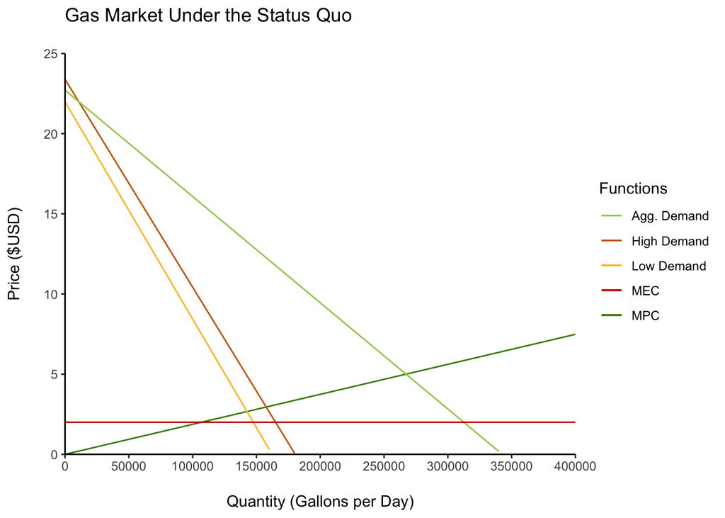

##### Figure 1. The gas market for France was analyzed by determining the high and low income demand curves, the aggregate demand curve, the marginal private cost for gasoline producers, and the marginal external costs derived from impacts to human health and the environment.

#### Equations for Figure 1.

High Income Demand: $P = (23.3914418-0.0001296638(Q))$

Low Income Demand: $P = (21.9908534-0.0001355174(Q))$

Aggregate Demand: $P = (22.70661-0.00006626299(Q))$

Marginal Private Cost: $P = (0.00001871138(Q))$

Marginal External Cost: $P = 2.00$

### II. Costs and Benefits at Status Quo

#### Equations for Benefits

Surplus General Calculation: $S = (1/2)(P)(Q)$

Aggregate Consumer Surplus: $CS = (1/2)(22.70661 - 5.00)(267217.062558)$ = $2,365,754

High Income Consumer Surplus: $CS = (1/2)(23.3914418 - 5.00)(141799.9)$ = $1,303,952

Low Income Consumer Surplus: $CS = (1/2)(21.9908534 - 5.00)(125393.8)$ = $1,065,274

Producer Surplus: $PS = (1/2)(5.00)(267217.062558)$ = $668,043

#### Equations for Costs

TEC General Calculation: $TEC = (MEC)(Q)$

Total Environmental Cost: $TEC = (2.00)(267217.062558)$ = $534,434

### III. Costs and Benefits with a $0.50/gallon Tax

#### Equations for Benefits

Surplus General Calculation: $S = (1/2)(P)(Q)$

High Income Consumer Surplus: $CS = (1/2)(23.3914418 - 5.3899)(138793.7)$ = $1,249,250

Low Income Consumer Surplus: $CS = (1/2)(21.9908534 - 5.3899)(122516.3)$ = $1,016,944

Producer Surplus: $PS = (1/2)(5.3899-.50)(261333)$ = $638,946

Tax Revenue General Calculation: $R = (Price~with~Tax - Price)(Q)$

Tax Revenue = $R = (5.3899-4.8899)(261333)$ = $130,667

#### Equations for Costs

Marginal Private Cost: $P = 0.50 + 00001871138(Q)$

TEC General Calculation: $TEC = (MEC)(Q)$

Total Environmental Cost: $TEC = (2.00)(261333)$ = $522,666

### IV. Costs and Benefits with Multiple Taxes

#### Equations for Benefits

a = Sum of All

Tax Revenue General Calculation: $R = (Price~with~Tax_a- Price_a)(Q)$ = $130,667

#### Equations for Costs

Total Environmental Cost: $TEC = (2.00)(Qa)$ = $522,666

| Potential Tax | High Income Consumer Surplus | Low Income Consumer Surplus | Producer Surplus |
| --- | --- | --- | --- |
| 0.5 | 1351493 | 596040.5 | 871506.5 |
| 1.0 | 1395253 | 657912.0 | 937420.8 |
| 1.5 | 1435598 | 716316.8 | 999394.5 |
| 2.0 | 1472527 | 771255.0 | 1057427.7 |
| 2.5 | 1506040 | 822726.5 | 1111520.2 |
| 3.0 | 1536136 | 870731.3 | 1161672.1 |
| 3.5 | 1562817 | 915269.6 | 1207883.4 |
| 4.0 | 1586082 | 956341.1 | 1250154.2 |
| 4.5 | 1605930 | 993946.0 | 1288484.3 |
| 5.0 | 1622363 | 1028084.3 | 1322873.8 |

### V. Costs and Benefits with the Introduction of Electric Vehicles

High Income Demand: $P = (11.69572-0.0001296638(Q))$

Low Income Demand: $P = (10.99543-0.0001355174(Q))$

Price: $P = (11.3533-00006626299(Q))$ = $4.87

#### Equations for Benefits

Surplus General Calculation: $S = (1/2)(P)(Q)$

High Income Consumer Surplus: $CS = (1/2)(11.69572 - 4.87)(51639.09)$ = $176,237

Low Income Consumer Surplus: $CS = (1/2)(10.99543 - 4.87)(46238.27)$ = $141,615

#### Equations for Costs

TEC General Calculation: $TEC = (MEC)(Q)$

Total Environmental Cost: $TEC = (2.00)(97877.36)$ = $195,755

### VI. Costs and Benefits of Gasoline with a $2.00 Tax

#### Equations for Costs

TEC General Calculation: $TEC = (MEC)(Q)$

Total Environmental Cost: $TEC = (2.00)(243680.6)$ = $487,361